# Project Python Foundations: FoodHub Data Analysis

**Marks: 60**

### Context

The number of restaurants in New York is increasing day by day. Lots of students and busy professionals rely on those restaurants due to their hectic lifestyles. Online food delivery service is a great option for them. It provides them with good food from their favorite restaurants. A food aggregator company FoodHub offers access to multiple restaurants through a single smartphone app.

The app allows the restaurants to receive a direct online order from a customer. The app assigns a delivery person from the company to pick up the order after it is confirmed by the restaurant. The delivery person then uses the map to reach the restaurant and waits for the food package. Once the food package is handed over to the delivery person, he/she confirms the pick-up in the app and travels to the customer's location to deliver the food. The delivery person confirms the drop-off in the app after delivering the food package to the customer. The customer can rate the order in the app. The food aggregator earns money by collecting a fixed margin of the delivery order from the restaurants.

### Objective

The food aggregator company has stored the data of the different orders made by the registered customers in their online portal. They want to analyze the data to get a fair idea about the demand of different restaurants which will help them in enhancing their customer experience. Suppose you are hired as a Data Scientist in this company and the Data Science team has shared some of the key questions that need to be answered. Perform the data analysis to find answers to these questions that will help the company to improve the business.

### Data Description

The data contains the different data related to a food order. The detailed data dictionary is given below.

### Data Dictionary

- order_id: Unique ID of the order
- customer_id: ID of the customer who ordered the food
- restaurant_name: Name of the restaurant
- cuisine_type: Cuisine ordered by the customer
- cost: Cost of the order
- day_of_the_week: Indicates whether the order is placed on a weekday or weekend (The weekday is from Monday to Friday and the weekend is Saturday and Sunday)
- rating: Rating given by the customer out of 5
- food_preparation_time: Time (in minutes) taken by the restaurant to prepare the food. This is calculated by taking the difference between the timestamps of the restaurant's order confirmation and the delivery person's pick-up confirmation.
- delivery_time: Time (in minutes) taken by the delivery person to deliver the food package. This is calculated by taking the difference between the timestamps of the delivery person's pick-up confirmation and drop-off information

### Let us start by importing the required libraries

```python
# import libraries for data manipulation
import numpy as np
import pandas as pd

# import libraries for data visualization
import matplotlib.pyplot as plt
import seaborn as sns
```

### Understanding the structure of the data

```python
# I upload the file directly to colab to read the data
df = pd.read_csv('foodhub_order.csv')
# returns the first 5 rows
df.head()
```

|  | order_id | customer_id | restaurant_name | cuisine_type | cost_of_the_order | day_of_the_week | rating | food_preparation_time | delivery_time |
| --- | --- | --- | --- | --- | --- | --- | --- | --- | --- |
| 0 | 1477147 | 337525 | Hangawi | Korean | 30.75 | Weekend | Not given | 25 | 20 |
| 1 | 1477685 | 358141 | Blue Ribbon Sushi Izakaya | Japanese | 12.08 | Weekend | Not given | 25 | 23 |
| 2 | 1477070 | 66393 | Cafe Habana | Mexican | 12.23 | Weekday | 5 | 23 | 28 |
| 3 | 1477334 | 106968 | Blue Ribbon Fried Chicken | American | 29.20 | Weekend | 3 | 25 | 15 |
| 4 | 1478249 | 76942 | Dirty Bird to Go | American | 11.59 | Weekday | 4 | 25 | 24 |

#### Observations:

The DataFrame has 9 columns as mentioned in the Data Dictionary. Data in each row corresponds to the order placed by a customer with order_id and customer_id to specify.

### **Question 1:** How many rows and columns are present in the data? [0.5 mark]

```python
df
```

|  | order_id | customer_id | restaurant_name | cuisine_type | cost_of_the_order | day_of_the_week | rating | food_preparation_time | delivery_time |
| --- | --- | --- | --- | --- | --- | --- | --- | --- | --- |
| 0 | 1477147 | 337525 | Hangawi | Korean | 30.75 | Weekend | Not given | 25 | 20 |
| 1 | 1477685 | 358141 | Blue Ribbon Sushi Izakaya | Japanese | 12.08 | Weekend | Not given | 25 | 23 |
| 2 | 1477070 | 66393 | Cafe Habana | Mexican | 12.23 | Weekday | 5 | 23 | 28 |
| 3 | 1477334 | 106968 | Blue Ribbon Fried Chicken | American | 29.20 | Weekend | 3 | 25 | 15 |
| 4 | 1478249 | 76942 | Dirty Bird to Go | American | 11.59 | Weekday | 4 | 25 | 24 |
| ... | ... | ... | ... | ... | ... | ... | ... | ... | ... |
| 1893 | 1476701 | 292602 | Chipotle Mexican Grill $1.99 Delivery | Mexican | 22.31 | Weekend | 5 | 31 | 17 |
| 1894 | 1477421 | 397537 | The Smile | American | 12.18 | Weekend | 5 | 31 | 19 |
| 1895 | 1477819 | 35309 | Blue Ribbon Sushi | Japanese | 25.22 | Weekday | Not given | 31 | 24 |
| 1896 | 1477513 | 64151 | Jack's Wife Freda | Mediterranean | 12.18 | Weekday | 5 | 23 | 31 |
| 1897 | 1478056 | 120353 | Blue Ribbon Sushi | Japanese | 19.45 | Weekend | Not given | 28 | 24 |

1898 rows × 9 columns

```python
df.info()
```

```
<class 'pandas.core.frame.DataFrame'>
RangeIndex: 1898 entries, 0 to 1897
Data columns (total 9 columns):
 #   Column                 Non-Null Count  Dtype
---  ------                 --------------  -----
 0   order_id               1898 non-null   int64
 1   customer_id            1898 non-null   int64
 2   restaurant_name        1898 non-null   object
 3   cuisine_type           1898 non-null   object
 4   cost_of_the_order      1898 non-null   float64
 5   day_of_the_week        1898 non-null   object
 6   rating                 1898 non-null   object
 7   food_preparation_time  1898 non-null   int64
 8   delivery_time          1898 non-null   int64
dtypes: float64(1), int64(4), object(4)
memory usage: 133.6+ KB
```

#### Observations: There are 9 columns within the datafram indexing from 0-8 in order as; order_id, customer_id, restaurant_name, cuisine_type, cost_of_the_order, day_of_the_week, rating, food_preparation_time, and delivery_time.

### **Question 2:** What are the datatypes of the different columns in the dataset? (The info() function can be used) [0.5 mark]

```python
# Use info() to print a concise summary of the DataFrame
df.info()
```

```
<class 'pandas.core.frame.DataFrame'>
RangeIndex: 1898 entries, 0 to 1897
Data columns (total 9 columns):
 #   Column                 Non-Null Count  Dtype
---  ------                 --------------  -----
 0   order_id               1898 non-null   int64
 1   customer_id            1898 non-null   int64
 2   restaurant_name        1898 non-null   object
 3   cuisine_type           1898 non-null   object
 4   cost_of_the_order      1898 non-null   float64
 5   day_of_the_week        1898 non-null   object
 6   rating                 1898 non-null   object
 7   food_preparation_time  1898 non-null   int64
 8   delivery_time          1898 non-null   int64
dtypes: float64(1), int64(4), object(4)
memory usage: 133.6+ KB
```

#### Observations: 'cost_of_the_order' is the only float, which makes sense as dollar orders typically are rounded out to the cent. We also have object for all string columns and int64 for all integer columns. Need to check on 'rating' column as is shows object in column with a numerical rating.

### **Question 3:** Are there any missing values in the data? If yes, treat them using an appropriate method. [1 mark]

```python
df.isnull().sum()
```

|  | 0 |
| --- | --- |
| order_id | 0 |
| customer_id | 0 |
| restaurant_name | 0 |
| cuisine_type | 0 |
| cost_of_the_order | 0 |
| day_of_the_week | 0 |
| rating | 0 |
| food_preparation_time | 0 |
| delivery_time | 0 |

**dtype:** int64

```python
df['rating'].unique()
```

```
array(['Not given', '5', '3', '4'], dtype=object)
```

```python
# Convert 'Not given' to NaN
df['rating'] = df['rating'].replace(['Not given'], np.nan)
# Convert type to float
df['rating'] = df['rating'].astype(float)
```

```python
df['rating'].value_counts()
```

| rating | count |
| --- | --- |
| 5.0 | 588 |
| 4.0 | 386 |
| 3.0 | 188 |

**dtype:** int64

```python
df.isnull().sum()
```

|  | 0 |
| --- | --- |
| order_id | 0 |
| customer_id | 0 |
| restaurant_name | 0 |
| cuisine_type | 0 |
| cost_of_the_order | 0 |
| day_of_the_week | 0 |
| rating | 736 |
| food_preparation_time | 0 |
| delivery_time | 0 |

**dtype:** int64

```python
# This was the code I was attempting to use to convert the NaN values in rating to a categorical mean.

#def fill_rating_with_criteria(row, df):
#     if np.isnan(row['rating']):
#         # Define the range for cost_of_the_order
#         cost_lower = row['cost_of_the_order'] - 5
#         cost_upper = row['cost_of_the_order'] + 5

#         # Filter rows that match the criteria
#         matching_rows = df[
#             (df['cuisine_type'] == row['cuisine_type']) &
#             (df['restaurant_name'] == row['restaurant_name']) &
#             (df['day_of_the_week'] == row['day_of_the_week']) &
#             (df['cost_of_the_order'] >= cost_lower) &
#             (df['cost_of_the_order'] <= cost_upper)
#         ]

#         # Calculate the mean rating for matching rows
#         mean_rating = matching_rows['rating'].mean()

#         # Return the rounded mean rating if available, otherwise leave as NaN
#         return round(mean_rating, 1) if not np.isnan(mean_rating) else np.nan
#     else:
#         # If the rating is not NaN, keep the original value
#         return row['rating']

# # Apply the function to fill the NaN values in the 'rating' column
# df['rating'] = df.apply(fill_rating_with_criteria, axis=1, df=df)

# # Check the first few rows to verify
# print(df['rating'].head())
```

#### Observations: While there are no NaN values present in the data set, there are 736 "Not given" ratings within the 'rating' column. I would consider these to be missing values and values that need to be ammended before performing analytics with the 'rating' column involved. So I converted these values to NaN. I Then provided a a line of code to fill in the NaN values in 'rating' with the mean of rows matched with the cuisine type, restaurant name, day of the week, and cost of the order within plus or minus $5. However, for the final analysis I decided to leave this code out as it would change the STD by about 12% which is too high for my liking.

### **Question 4:** Check the statistical summary of the data. What is the minimum, average, and maximum time it takes for food to be prepared once an order is placed? [2 marks]

```python
df.describe().T
```

|  | count | mean | std | min | 25% | 50% | 75% | max |
| --- | --- | --- | --- | --- | --- | --- | --- | --- |
| order_id | 1898.0 | 1.477496e+06 | 548.049724 | 1476547.00 | 1477021.25 | 1477495.50 | 1.477970e+06 | 1478444.00 |
| customer_id | 1898.0 | 1.711685e+05 | 113698.139743 | 1311.00 | 77787.75 | 128600.00 | 2.705250e+05 | 405334.00 |
| cost_of_the_order | 1898.0 | 1.649885e+01 | 7.483812 | 4.47 | 12.08 | 14.14 | 2.229750e+01 | 35.41 |
| rating | 1162.0 | 4.344234e+00 | 0.741478 | 3.00 | 4.00 | 5.00 | 5.000000e+00 | 5.00 |
| food_preparation_time | 1898.0 | 2.737197e+01 | 4.632481 | 20.00 | 23.00 | 27.00 | 3.100000e+01 | 35.00 |
| delivery_time | 1898.0 | 2.416175e+01 | 4.972637 | 15.00 | 20.00 | 25.00 | 2.800000e+01 | 33.00 |

#### Observations: 'food_preparation_time' shows us the difference between the timestamps of the restaurant's order confirmation and the delivery person's pick-up confirmation. The statistics behind this difference are as follows: minimum = 20.00 minutes, average ~ 27.37 minutes, maximum = 35.00 minutes.

### **Question 5:** How many orders are not rated? [1 mark]

```python
df['rating'].value_counts()
```

| rating | count |
| --- | --- |
| 5.0 | 588 |
| 4.0 | 386 |
| 3.0 | 188 |

**dtype:** int64

```python
df['rating'].isnull().sum()
```

```
736
```

#### Observations: 736 orders are not rated within the 'rating' column.

### Exploratory Data Analysis (EDA)

### **Question 6:** Explore all the variables and provide observations on their distributions. (Generally, histograms, boxplots, countplots, etc. are used for univariate exploration.) [9 marks]

```python
df.info()
```

```
<class 'pandas.core.frame.DataFrame'>
RangeIndex: 1898 entries, 0 to 1897
Data columns (total 9 columns):
 #   Column                 Non-Null Count  Dtype
---  ------                 --------------  -----
 0   order_id               1898 non-null   int64
 1   customer_id            1898 non-null   int64
 2   restaurant_name        1898 non-null   object
 3   cuisine_type           1898 non-null   object
 4   cost_of_the_order      1898 non-null   float64
 5   day_of_the_week        1898 non-null   object
 6   rating                 1162 non-null   float64
 7   food_preparation_time  1898 non-null   int64
 8   delivery_time          1898 non-null   int64
dtypes: float64(2), int64(4), object(3)
memory usage: 133.6+ KB
```

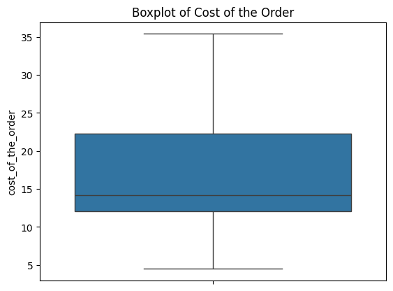

```python
sns.boxplot(df['cost_of_the_order'])
plt.title('Boxplot of Cost of the Order')
plt.show()
```

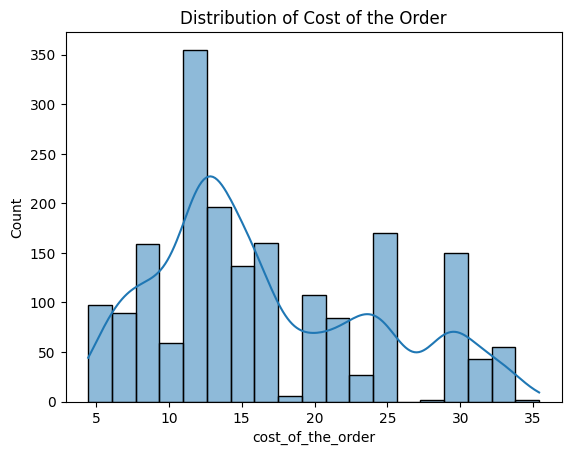

```python
sns.histplot(df['cost_of_the_order'], kde=True)
plt.title('Distribution of Cost of the Order')
plt.show()
```

```python
np.floor(df['cost_of_the_order']).value_counts()
```

| cost_of_the_order | count |
| --- | --- |
| 12.0 | 340 |
| 29.0 | 150 |
| 14.0 | 143 |
| 16.0 | 126 |
| 24.0 | 117 |
| 9.0 | 105 |
| 15.0 | 101 |
| 8.0 | 96 |
| 6.0 | 91 |
| 19.0 | 86 |
| 13.0 | 73 |
| 5.0 | 70 |
| 22.0 | 70 |
| 25.0 | 53 |
| 11.0 | 48 |
| 31.0 | 42 |
| 21.0 | 40 |
| 32.0 | 30 |
| 33.0 | 25 |
| 7.0 | 23 |
| 20.0 | 23 |
| 17.0 | 18 |
| 10.0 | 10 |
| 4.0 | 9 |
| 18.0 | 4 |
| 28.0 | 2 |
| 30.0 | 1 |
| 35.0 | 1 |
| 34.0 | 1 |

**dtype:** int64

```python
df['cost_of_the_order'].describe().T
```

|  | cost_of_the_order |
| --- | --- |
| count | 1898.000000 |
| mean | 16.498851 |
| std | 7.483812 |
| min | 4.470000 |
| 25% | 12.080000 |
| 50% | 14.140000 |
| 75% | 22.297500 |
| max | 35.410000 |

**dtype:** float64

COST_OF_THE_ORDER OBSERVATION: The cost of orders data is skewed slightly to the right with 50% of the orders costing between 4.47USD to 14.14USD and the other 50% of orders costing between 14.14USD and 35.41USD (a slightly larger IQR between the top half of the data). There seem to be no extreme outliers here, but rather a majority of orders between about 5USD and 17USD, a bundle of orders between about 19USD and 25USD, and finally, a group of orders pulling data to the right that cost between about 29USD to 34USD. When rounding this column to the nearest whole number, 12USD is the cost of order 2x more frequently than the second place cost. Following that, 29USD, 14USD, 16USD, and 24USD trail tightly together.

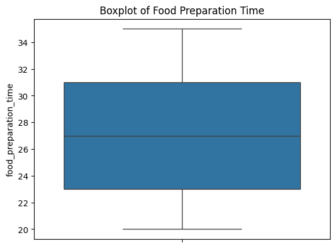

```python
sns.boxplot(df['food_preparation_time'])
plt.title('Boxplot of Food Preparation Time')
plt.show()
```

```python
df['food_preparation_time'].describe().T
```

|  | food_preparation_time |
| --- | --- |
| count | 1898.000000 |
| mean | 27.371970 |
| std | 4.632481 |
| min | 20.000000 |
| 25% | 23.000000 |
| 50% | 27.000000 |
| 75% | 31.000000 |
| max | 35.000000 |

**dtype:** float64

```python
df['food_preparation_time'].value_counts()
```

| food_preparation_time | count |
| --- | --- |
| 21 | 135 |
| 23 | 123 |
| 27 | 123 |
| 22 | 123 |
| 28 | 121 |
| 24 | 121 |
| 20 | 119 |
| 30 | 119 |
| 33 | 118 |
| 35 | 117 |
| 31 | 116 |
| 26 | 115 |
| 25 | 113 |
| 34 | 113 |
| 32 | 113 |
| 29 | 109 |

**dtype:** int64

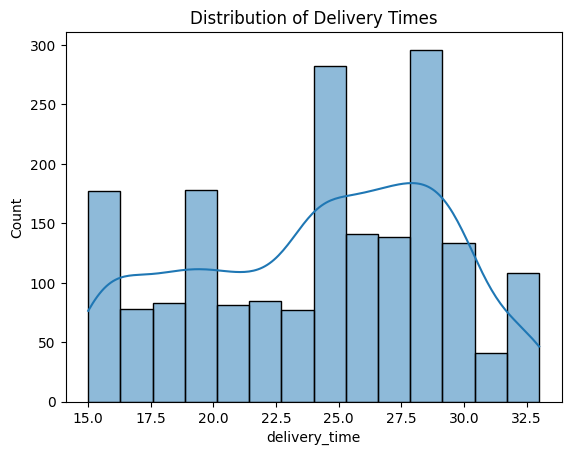

```python
sns.histplot(df['delivery_time'], kde=True)
plt.title('Distribution of Delivery Times')
plt.show()
```

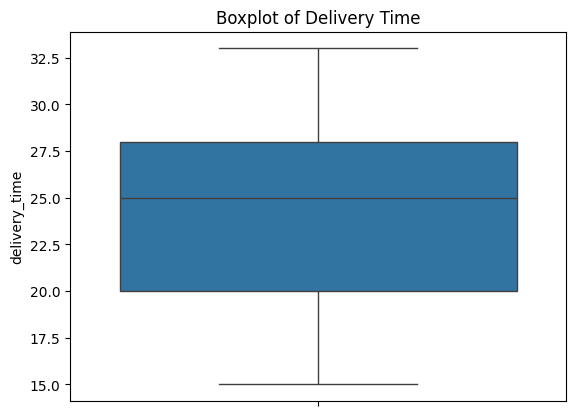

```python
sns.boxplot(df['delivery_time'])
plt.title('Boxplot of Delivery Time')
plt.show()
```

```python
df['delivery_time'].describe().T
```

|  | delivery_time |
| --- | --- |
| count | 1898.000000 |
| mean | 24.161749 |
| std | 4.972637 |
| min | 15.000000 |
| 25% | 20.000000 |
| 50% | 25.000000 |
| 75% | 28.000000 |
| max | 33.000000 |

**dtype:** float64

DELIVERY_TIME OBSERVATION: There are no outliers here with a minimum delivery time of 15 minutes and a maximum of 33 minutes. The data is slightly skewed left as there is a slightly larger spread between the minimum delivery time and median delivery time. Again, there is not much to pull from this data without cross analysis using data from (possibly) the rating, restaurant_name, or other columns.

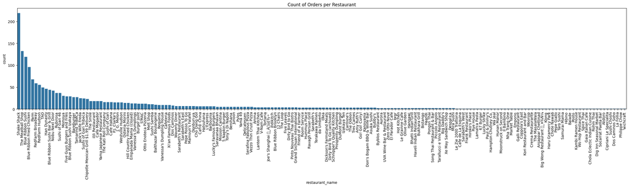

```python
plt.figure(figsize=(30,5))
#Using the only index values of the automatically ordered value_counts function
#to order this countplot from highest to lowest with regards to count
sns.countplot(x='restaurant_name', data=df, order=df['restaurant_name'].value_counts().index)
plt.xticks(rotation=90)
plt.title('Count of Orders per Restaurant')
plt.show()
```

```python
df['restaurant_name'].value_counts().head(20)
```

| restaurant_name | count |
| --- | --- |
| Shake Shack | 219 |
| The Meatball Shop | 132 |
| Blue Ribbon Sushi | 119 |
| Blue Ribbon Fried Chicken | 96 |
| Parm | 68 |
| RedFarm Broadway | 59 |
| RedFarm Hudson | 55 |
| TAO | 49 |
| Han Dynasty | 46 |
| Blue Ribbon Sushi Bar & Grill | 44 |
| Nobu Next Door | 42 |
| Rubirosa | 37 |
| Sushi of Gari 46 | 37 |
| Momoya | 30 |
| Five Guys Burgers and Fries | 29 |
| Blue Ribbon Sushi Izakaya | 29 |
| Bareburger | 27 |
| Tamarind TriBeCa | 27 |
| Jack's Wife Freda | 25 |
| Sushi of Gari Tribeca | 24 |

**dtype:** int64

```python
df['restaurant_name'].nunique()
```

```
178
```

RESTAURANT_NAME OBSERVATION: While the countplot is hard to read, it gives a vizualization of how the top few restaurants dominate the order volume in a dataset with 178 restaruants inside of it. The top five restaurants based on order volume in the dataset are: Shake Shack 219, The Meatball Shop 132, Blue Ribbon Sushi 119, Blue Ribbon Fried Chicken 96, Parm 68. With 1898 rows of data, just these top 5 restaurants make up 33.40% of the total orders within the data.

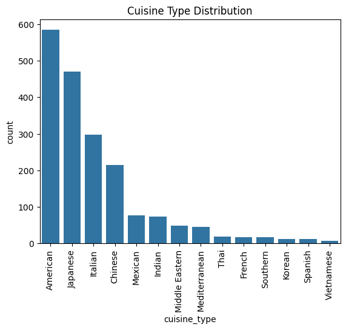

```python
sns.countplot(x='cuisine_type', data=df, order=df['cuisine_type'].value_counts().index)
plt.xticks(rotation=90)
plt.title('Cuisine Type Distribution')
plt.show()
```

```python
df['cuisine_type'].value_counts()
```

| cuisine_type | count |
| --- | --- |
| American | 584 |
| Japanese | 470 |
| Italian | 298 |
| Chinese | 215 |
| Mexican | 77 |
| Indian | 73 |
| Middle Eastern | 49 |
| Mediterranean | 46 |
| Thai | 19 |
| French | 18 |
| Southern | 17 |
| Korean | 13 |
| Spanish | 12 |
| Vietnamese | 7 |

**dtype:** int64

CUISINE_TYPE OBSERVATION: Similar to the name of restaurant column, the cuisine type is dominated by only a few. The top four stand out much further than the rest, and those are: American 584, Japanese 470, Italian 298, and Chinese 215. These four cuisine types account for an astounding 82.56% of the total orders within the data.

```python
df['day_of_the_week'].value_counts()
```

| day_of_the_week | count |
| --- | --- |
| Weekend | 1351 |
| Weekday | 547 |

**dtype:** int64

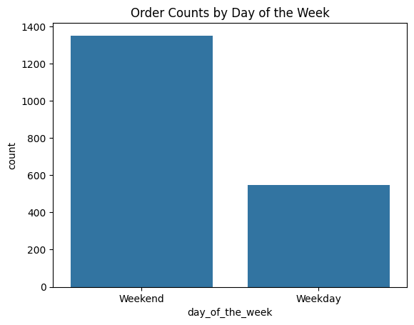

```python
sns.countplot(x='day_of_the_week', data=df, order=['Weekend', 'Weekday'])
plt.title('Order Counts by Day of the Week')
plt.show()
```

DAY_OF_THE_WEEK OBSERVATION: Weekends account for 71.18% of the total orders within this data set. It will be worth looking into the difference in std when doing multivariate analysis between weekends & rating/delivery_time/cost_of_the_order vs. weekdays & rating/delivery_time/cost_of_the_order. My assumption is that weekends will prove to be more profitable at the cost of more poor ratings, longer delivery times, etc.

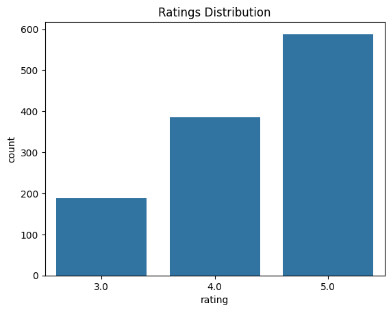

```python
sns.countplot(x='rating', data=df)
plt.title('Ratings Distribution')
plt.show()
```

```python
df['rating'].describe().T
```

|  | rating |
| --- | --- |
| count | 1162.000000 |
| mean | 4.344234 |
| std | 0.741478 |
| min | 3.000000 |
| 25% | 4.000000 |
| 50% | 5.000000 |
| 75% | 5.000000 |
| max | 5.000000 |

**dtype:** float64

RATING OBSERVATION: Too many ratings are NaN to consider this column within our final analysis and observations.

### **Question 7**: Which are the top 5 restaurants in terms of the number of orders received? [1 mark]

```python
df['restaurant_name'].value_counts().head(5)
```

| restaurant_name | count |
| --- | --- |
| Shake Shack | 219 |
| The Meatball Shop | 132 |
| Blue Ribbon Sushi | 119 |
| Blue Ribbon Fried Chicken | 96 |
| Parm | 68 |

**dtype:** int64

#### Observations: The top 5 restaurants in terms of number of orders recieved are Shake Shack, The Meatball Shop, Blue Ribbon, Sushi, Blue Ribbon, Fried Chicken, Parm. These 5 account for around 33.40% of the total orders recieved within this data set.

### **Question 8**: Which is the most popular cuisine on weekends? [1 mark]

```python
df[df['day_of_the_week'] == 'Weekend']['cuisine_type'].value_counts().head()
```

| cuisine_type | count |
| --- | --- |
| American | 415 |
| Japanese | 335 |
| Italian | 207 |
| Chinese | 163 |
| Mexican | 53 |

**dtype:** int64

#### Observations: American is the most popular with 415 orders on the Weekend, followed by Japanese (335), Italian (207), Chinese (163), and Mexican (53)

### **Question 9**: What percentage of the orders cost more than 20 dollars? [2 marks]

```python
#total number of rows in the df
df.shape[0]
```

```
1898
```

```python
#total number of rows in the df with a 'cost_of_the_order' > 20
df[df['cost_of_the_order']>20].shape[0]
```

```
555
```

```python
#number of rows with coto>20 divided by total n of rows times 100, rounded to 2nd decimal
perc_over_20 = round((df[df['cost_of_the_order']>20].shape[0]/df.shape[0])*100,2)
print(f"{perc_over_20}% of the orders cost more than $20.")
```

```
29.24% of the orders cost more than $20.
```

#### Observations: 29.24% of orders cost more than 20USD.

### **Question 10**: What is the mean order delivery time? [1 mark]

```python
#rounding the mean of all values in the delivery_time column to the 2nd decimal
mean_delivery = round(df['delivery_time'].mean(),2)
print(f"The mean order delivery time is {mean_delivery} minutes.")
```

```
The mean order delivery time is 24.16 minutes.
```

#### Observations: 24.16 minutes is the average order delivery time.

### **Question 11:** The company has decided to give 20% discount vouchers to the top 5 most frequent customers. Find the IDs of these customers and the number of orders they placed. [1 mark]

```python
df['customer_id'].value_counts().head(9)
```

| customer_id | count |
| --- | --- |
| 52832 | 13 |
| 47440 | 10 |
| 83287 | 9 |
| 250494 | 8 |
| 259341 | 7 |
| 82041 | 7 |
| 65009 | 7 |
| 276192 | 7 |
| 97079 | 6 |

**dtype:** int64

```python
# Get the customer IDs with exactly 7 orders
customers_with_7_orders = df['customer_id'].value_counts()[df['customer_id'].value_counts() == 7].index

# Filter the DataFrame for those customer IDs
df_filtered = df[df['customer_id'].isin(customers_with_7_orders)]

# Group by customer_id and sum the cost_of_the_order for each customer
total_spent_by_each_customer = df_filtered.groupby('customer_id')['cost_of_the_order'].sum()

# Display the result
print(total_spent_by_each_customer)
```

```
customer_id
65009      99.49
82041     120.92
259341    130.81
276192    146.46
Name: cost_of_the_order, dtype: float64
```

#### Observations: The top four customers are obvious, but the 5th to 8th customer are all in a tie with 7 orders each. So to decide the 5th customer I've used some code to find who has spent the most out of those four customers tied with 7 orders. The final 5 customers recieving discounts are 52832, 47440, 83287, 250494, and 276192.

### **Question 12**: Perform a multivariate analysis to explore relationships between the important variables in the dataset. (It is a good idea to explore relations between numerical variables as well as relations between numerical and categorical variables) [10 marks]

analyze the data to get a fair idea about the demand of different restaurants which will help them in enhancing their customer experience.

1. Day of the week vs. Delivery time
2. Cost of order vs. Food prep time
3. Cuisine type vs. Food Prep Time vs. Delivery Time
4. Cuisine type vs. Day of the Week vs. Cost of Order
5. (value count top 10)Restaurant Name vs. Day of the Week
6. (value count top 10)Restrauant Name vs. Day of the Week vs. Delivery Time
7. Avg Cost of Order vs. Cuisine Type
8. Avg Delivery Time vs. Cuisine Type
9. Avg Food Prep Time vs. Cuisine Type
10. Avg Total Order to Deliver Time vs. Cuisine Type
11. Total Delivery Time of Each Cuisine vs. Day of the Week
12. Correlation Matrix of numerical columns

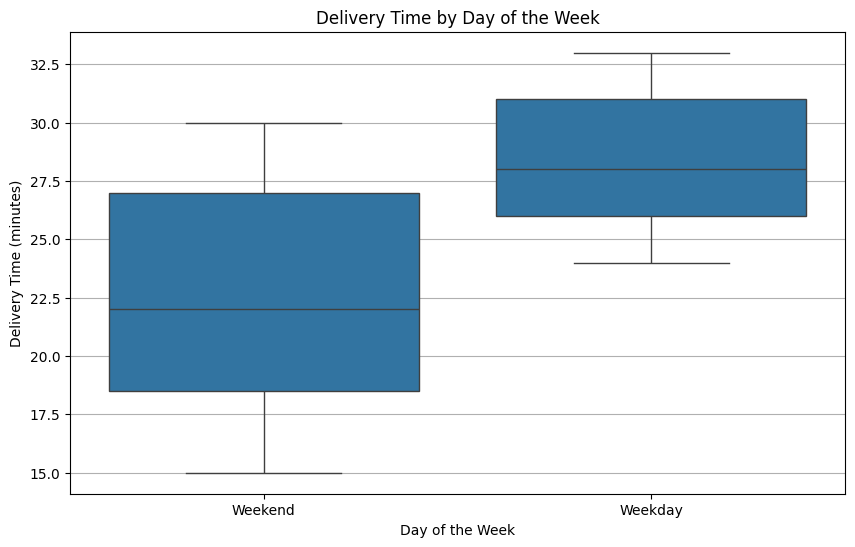

```python
#Create size plot for the figure
plt.figure(figsize=(10, 6))
#Creating the box plot
sns.boxplot(x='day_of_the_week',
            y='delivery_time',
            data=df)
#Add specifications to the chart
plt.title('Delivery Time by Day of the Week')
plt.xlabel('Day of the Week')
plt.ylabel('Delivery Time (minutes)')
plt.grid(axis='y')
plt.show()
```

```python
# Statistical summary of the delivery time column grouped by the day_of_the_week
# column values
df.groupby('day_of_the_week')['delivery_time'].describe()
```

| day_of_the_week | count | mean | std | min | 25% | 50% | 75% | max |
| --- | --- | --- | --- | --- | --- | --- | --- | --- |
| Weekday | 547.0 | 28.340037 | 2.891428 | 24.0 | 26.0 | 28.0 | 31.0 | 33.0 |
| Weekend | 1351.0 | 22.470022 | 4.628938 | 15.0 | 18.5 | 22.0 | 27.0 | 30.0 |

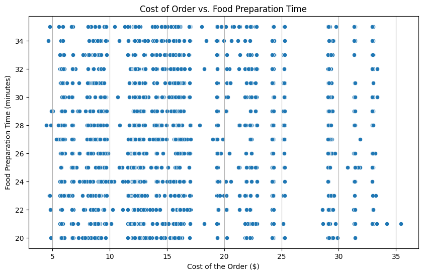

```python
plt.figure(figsize=(10, 6))
#Creating the scatterplot
sns.scatterplot(x='cost_of_the_order',
                y='food_preparation_time',
                data=df)
plt.title('Cost of Order vs. Food Preparation Time')
plt.xlabel('Cost of the Order ($)')
plt.ylabel('Food Preparation Time (minutes)')
plt.grid(axis='x')
plt.show()
```

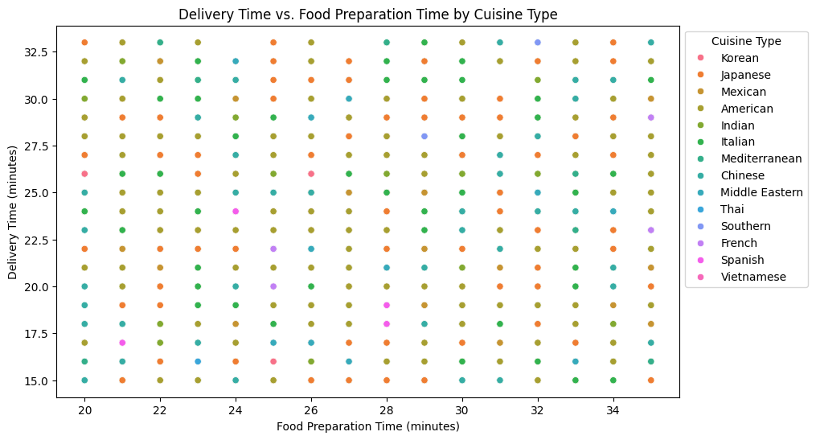

```python
plt.figure(figsize=(10, 6))
sns.scatterplot(x='food_preparation_time',
                y='delivery_time',
                hue='cuisine_type',
                data=df)
plt.title('Delivery Time vs. Food Preparation Time by Cuisine Type')
plt.xlabel('Food Preparation Time (minutes)')
plt.ylabel('Delivery Time (minutes)')
#Using legend specifics for multivariate analysis clarity
plt.legend(title='Cuisine Type', bbox_to_anchor=(1, 1))
plt.show()
```

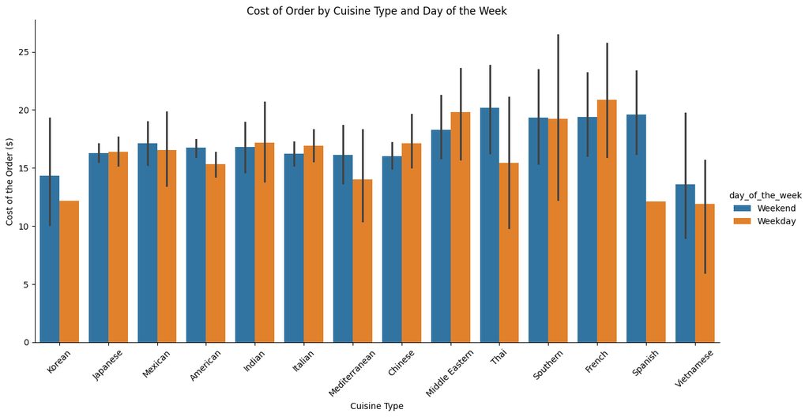

```python
sns.catplot(x='cuisine_type',
            y='cost_of_the_order',
            hue='day_of_the_week',
            data=df,
            kind='bar',
            #To spread the plot vertically
            height=6,
            #To spread the plot horizontally
            aspect=2)
plt.title('Cost of Order by Cuisine Type and Day of the Week')
plt.xlabel('Cuisine Type')
plt.ylabel('Cost of the Order ($)')
plt.xticks(rotation=45)
plt.show()
```

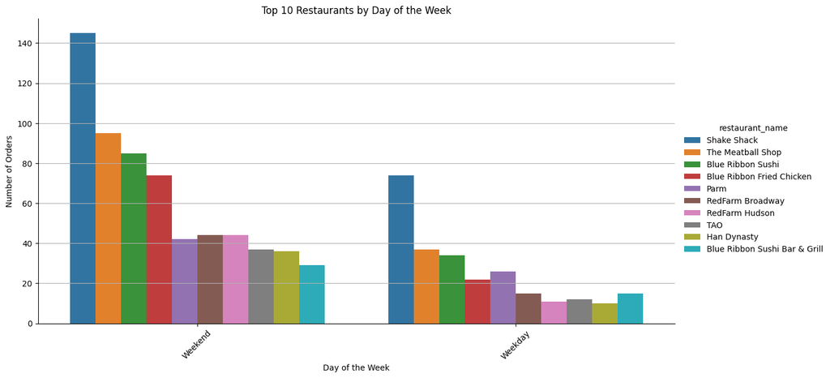

```python
#Creating a value to extract only the restaurant name(index) from the top ten
#restaurants with regards to frequency in the dataset
top_restaurants = df['restaurant_name'].value_counts().head(10).index

#Creating a new dataframe that includes all of the data from our original df but
#only for the 'restaurant_name's that are within the top 10 value count
df_top_restaurants = df[df['restaurant_name'].isin(top_restaurants)]

sns.catplot(
    x='day_of_the_week',
    hue='restaurant_name',
    data=df_top_restaurants,
    kind='count',
    height=6,
    aspect=2,
    hue_order=top_restaurants)
plt.title('Top 10 Restaurants by Day of the Week')
plt.xlabel('Day of the Week')
plt.ylabel('Number of Orders')
plt.xticks(rotation=45)
plt.grid(axis='y')
plt.show()
```

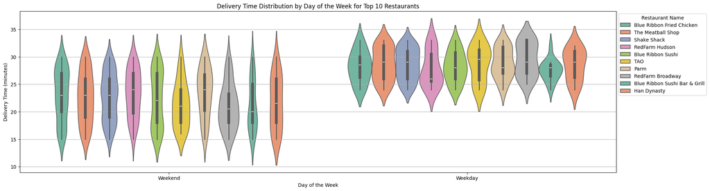

```python
plt.figure(figsize=(22, 6))
sns.violinplot(
    x='day_of_the_week',
    y='delivery_time',
    #Using a dataframe created earlier to organize chart amongst the top 10
    #restaurants based on total order count
    hue=df[df['restaurant_name'].isin(top_restaurants)]['restaurant_name'],
    data=df,
    palette='Set2'
    )
plt.title('Delivery Time Distribution by Day of the Week for Top 10 Restaurants')
plt.xlabel('Day of the Week')
plt.ylabel('Delivery Time (minutes)')
plt.legend(title='Restaurant Name', bbox_to_anchor=(1, 1))
plt.grid(axis='y')
plt.show()
```

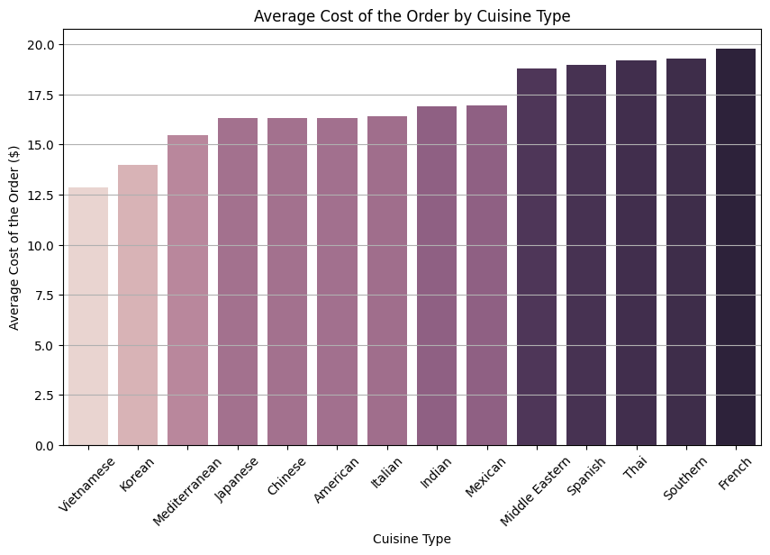

```python
#Creating a value to compute the average cost of ordering from each cuisine and
#sorting them in ascending order
avg_cost_by_cuisine = df.groupby('cuisine_type')['cost_of_the_order'].mean().sort_values()

plt.figure(figsize=(10, 6))
sns.barplot(
    x=avg_cost_by_cuisine.index,
    y=avg_cost_by_cuisine.values,
    hue=avg_cost_by_cuisine,
    legend=False
)
plt.title('Average Cost of the Order by Cuisine Type')
plt.xlabel('Cuisine Type')
plt.ylabel('Average Cost of the Order ($)')
plt.xticks(rotation=45)
plt.grid(axis='y')
plt.show()
```

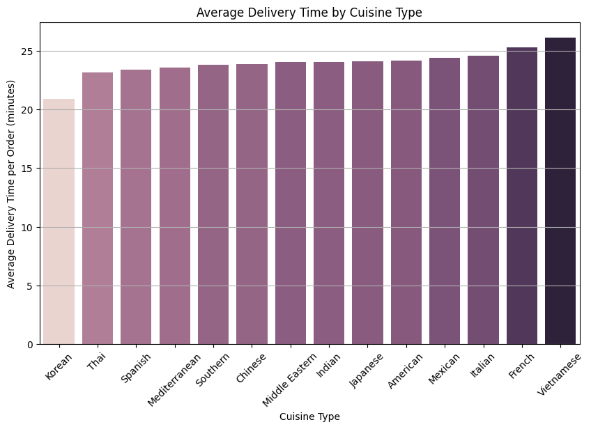

```python
avg_dtime_by_cuisine = df.groupby('cuisine_type')['delivery_time'].mean().sort_values()

plt.figure(figsize=(10, 6))
sns.barplot(
    x=avg_dtime_by_cuisine.index,
    y=avg_dtime_by_cuisine.values,
    hue=avg_dtime_by_cuisine,
    legend=False
)
plt.title('Average Delivery Time by Cuisine Type')
plt.xlabel('Cuisine Type')
plt.ylabel('Average Delivery Time per Order (minutes)')
plt.xticks(rotation=45)
plt.grid(axis='y')
plt.show()
```

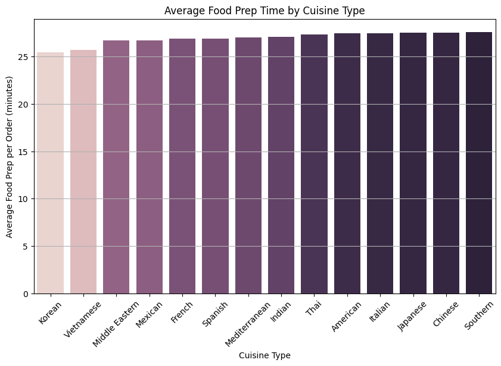

```python
avg_preptime_by_cuisine = df.groupby('cuisine_type')['food_preparation_time'].mean().sort_values()

plt.figure(figsize=(10, 6))
sns.barplot(
    x=avg_preptime_by_cuisine.index,
    y=avg_preptime_by_cuisine.values,
    hue=avg_preptime_by_cuisine,
    legend=False
)
plt.title('Average Food Prep Time by Cuisine Type')
plt.xlabel('Cuisine Type')
plt.ylabel('Average Food Prep per Order (minutes)')
plt.xticks(rotation=45)
plt.grid(axis='y')
plt.show()
```

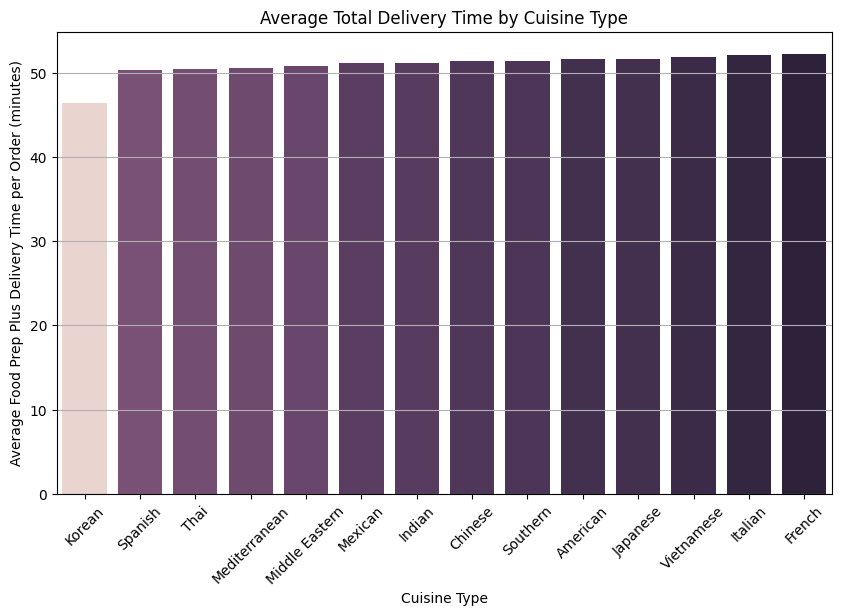

```python
avg_dtime_by_cuisine = df.groupby('cuisine_type')['delivery_time'].mean().sort_values()
avg_preptime_by_cuisine = df.groupby('cuisine_type')['food_preparation_time'].mean().sort_values()
total_time_by_cuisine = (avg_dtime_by_cuisine + avg_preptime_by_cuisine).sort_values()

plt.figure(figsize=(10, 6))
sns.barplot(
    x=total_time_by_cuisine.index,
    y=total_time_by_cuisine.values,
    hue=total_time_by_cuisine,
    legend=False
)
plt.title('Average Total Delivery Time by Cuisine Type')
plt.xlabel('Cuisine Type')
plt.ylabel('Average Food Prep Plus Delivery Time per Order (minutes)')
plt.xticks(rotation=45)
plt.grid(axis='y')
plt.show()
```

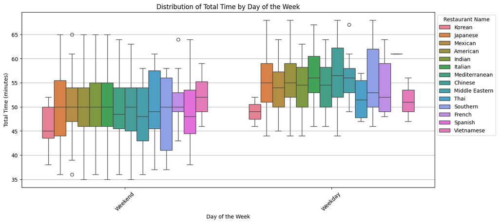

```python
#creating a total_time value within our df to call upon
df['total_time'] = df['delivery_time'] + df['food_preparation_time']

plt.figure(figsize=(14, 6))
sns.boxplot(
    x='day_of_the_week',
    y='total_time',
    data=df,
    hue='cuisine_type')
plt.title('Distribution of Total Time by Day of the Week')
plt.xlabel('Day of the Week')
plt.ylabel('Total Time (minutes)')
plt.xticks(rotation=45)
plt.legend(title='Restaurant Name', bbox_to_anchor=(1, 1))
plt.grid(axis='y')
plt.show()
```

```python
df.groupby('cuisine_type')['total_time'].describe()
```

| cuisine_type | count | mean | std | min | 25% | 50% | 75% | max |
| --- | --- | --- | --- | --- | --- | --- | --- | --- |
| American | 584.0 | 51.633562 | 6.616107 | 35.0 | 47.00 | 51.0 | 56.00 | 68.0 |
| Chinese | 215.0 | 51.367442 | 7.362437 | 35.0 | 46.00 | 51.0 | 56.50 | 68.0 |
| French | 18.0 | 52.222222 | 6.025002 | 43.0 | 49.00 | 50.5 | 56.75 | 64.0 |
| Indian | 73.0 | 51.191781 | 6.520603 | 36.0 | 47.00 | 51.0 | 56.00 | 65.0 |
| Italian | 298.0 | 52.050336 | 6.764496 | 35.0 | 47.25 | 53.0 | 56.00 | 67.0 |
| Japanese | 470.0 | 51.642553 | 6.993440 | 36.0 | 47.00 | 52.0 | 56.00 | 68.0 |
| Korean | 13.0 | 46.384615 | 4.519190 | 38.0 | 44.00 | 45.0 | 51.00 | 52.0 |
| Mediterranean | 46.0 | 50.586957 | 7.206713 | 36.0 | 46.25 | 50.0 | 55.00 | 64.0 |
| Mexican | 77.0 | 51.116883 | 5.891506 | 36.0 | 48.00 | 51.0 | 55.00 | 65.0 |
| Middle Eastern | 49.0 | 50.755102 | 7.221296 | 36.0 | 47.00 | 53.0 | 56.00 | 67.0 |
| Southern | 17.0 | 51.411765 | 8.602753 | 37.0 | 46.00 | 53.0 | 56.00 | 68.0 |
| Spanish | 12.0 | 50.333333 | 8.060378 | 38.0 | 45.25 | 49.0 | 57.25 | 64.0 |
| Thai | 19.0 | 50.473684 | 7.152066 | 37.0 | 47.00 | 49.0 | 57.00 | 61.0 |
| Vietnamese | 7.0 | 51.857143 | 4.740906 | 46.0 | 48.50 | 51.0 | 55.00 | 59.0 |

```python
correlation_matrix = df[['rating', 'cost_of_the_order', 'delivery_time', 'food_preparation_time', 'total_time']].corr()
```

```python
print(correlation_matrix)
```

```
                         rating  cost_of_the_order  delivery_time  \
rating                 1.000000           0.033983      -0.009804
cost_of_the_order      0.033983           1.000000      -0.029949
delivery_time         -0.009804          -0.029949       1.000000
food_preparation_time -0.006083           0.041527       0.011094
total_time            -0.011348           0.006358       0.735195

                       food_preparation_time  total_time
rating                             -0.006083   -0.011348
cost_of_the_order                   0.041527    0.006358
delivery_time                       0.011094    0.735195
food_preparation_time               1.000000    0.685970
total_time                          0.685970    1.000000
```

```python
#taking the mean of all costs of orders and ranking them
#in descending order
top_10_restaurants = df.groupby('restaurant_name')['cost_of_the_order'].mean().sort_values(ascending=False).head(10)
print(top_10_restaurants)
```

```
restaurant_name
Kambi Ramen House      32.930000
Emporio                31.430000
Bhatti Indian Grill    31.115000
Haru Gramercy Park     29.830000
Lucky Strike           29.250000
Il Bambino             29.250000
Sarabeth's             29.133333
Rohm Thai              29.100000
Klong                  29.050000
67 Burger              29.050000
Name: cost_of_the_order, dtype: float64
```

```python
#pythonic version with nlargest function I just found
top_10_restaurants = df.groupby('restaurant_name')['cost_of_the_order'].mean().nlargest(10)
print(top_10_restaurants)
```

```
restaurant_name
Kambi Ramen House      32.930000
Emporio                31.430000
Bhatti Indian Grill    31.115000
Haru Gramercy Park     29.830000
Il Bambino             29.250000
Lucky Strike           29.250000
Sarabeth's             29.133333
Rohm Thai              29.100000
67 Burger              29.050000
Klong                  29.050000
Name: cost_of_the_order, dtype: float64
```

```python
df['restaurant_name'].value_counts().head(15)
```

| restaurant_name | count |
| --- | --- |
| Shake Shack | 219 |
| The Meatball Shop | 132 |
| Blue Ribbon Sushi | 119 |
| Blue Ribbon Fried Chicken | 96 |
| Parm | 68 |
| RedFarm Broadway | 59 |
| RedFarm Hudson | 55 |
| TAO | 49 |
| Han Dynasty | 46 |
| Blue Ribbon Sushi Bar & Grill | 44 |
| Nobu Next Door | 42 |
| Rubirosa | 37 |
| Sushi of Gari 46 | 37 |
| Momoya | 30 |
| Five Guys Burgers and Fries | 29 |

**dtype:** int64

**Observations:**

### **Question 13:** The company wants to provide a promotional offer in the advertisement of the restaurants. The condition to get the offer is that the restaurants must have a rating count of more than 50 and the average rating should be greater than 4. Find the restaurants fulfilling the criteria to get the promotional offer. [3 marks]

```python
# First, group by restaurant_name and calculate the rating count and average rating
restaurant_ratings = df.groupby('restaurant_name')['rating'].agg(['count', 'mean'])

# Now, filter the restaurants that have more than 50 ratings and average rating greater than 4
promotional_restaurants = restaurant_ratings[(restaurant_ratings['count'] > 50) & (restaurant_ratings['mean'] > 4)]

# Display the restaurant names that meet the criteria
print(promotional_restaurants)
```

```
                           count      mean
restaurant_name
Blue Ribbon Fried Chicken     64  4.328125
Blue Ribbon Sushi             73  4.219178
Shake Shack                  133  4.278195
The Meatball Shop             84  4.511905
```

#### Observations: Shake Shack, The Meatball Shop, Blue Ribbon Sushi, and Blue Ribbon Fried Chicken all meet this critera of having over 50 total reviews and an average review score greater than 4.

### **Question 14:** The company charges the restaurant 25% on the orders having cost greater than 20 dollars and 15% on the orders having cost greater than 5 dollars. Find the net revenue generated by the company across all orders. [3 marks]

```python
#create a function to define commission
def commission_rev(x):

#if statements to determine pricing values
    if x > 20:
        return x*0.25
    elif x > 5:
        return x*0.15
    else:
        return 0

#applying the if statements to all values in cost_of_the_order
#and creating a new column with these values
df['commission'] = df['cost_of_the_order'].apply(commission_rev)

#adding up all values in the new column to get the total revenue
net_revenue = df['commission'].sum()

print(f"Total Net Revenue: ${net_revenue:.2f}")
```

```
Total Net Revenue: $6166.30
```

```python
#checking if that value makes sense
df['commission'].value_counts()
```

| commission | count |
| --- | --- |
| 1.8270 | 86 |
| 1.8195 | 82 |
| 1.8345 | 47 |
| 6.0500 | 42 |
| 7.2750 | 37 |
| ... | ... |
| 5.5300 | 1 |
| 0.8220 | 1 |
| 2.5605 | 1 |
| 0.9390 | 1 |
| 7.3975 | 1 |

306 rows × 1 columns

**dtype:** int64

### **Question 15:** The company wants to analyze the total time required to deliver the food. What percentage of orders take more than 60 minutes to get delivered from the time the order is placed? (The food has to be prepared and then delivered.) [2 marks]

```python
df['total_time'] = df['delivery_time'] + df['food_preparation_time']

perc_over_60 = round((df[df['total_time']>60].shape[0]/df.shape[0])*100,2)
print(f"{perc_over_60}% of orders take more than 60 minutes to get delivered.")
```

```
10.54% of orders take more than 60 minutes to get delivered.
```

#### Observations: 10.54% of orders take more than 60 minutes to get delivered. This may be the most important metric to improve on, especially considering weekday delivery times vs. weekend delivery times which was covered earlier on.

### **Question 16:** The company wants to analyze the delivery time of the orders on weekdays and weekends. How does the mean delivery time vary during weekdays and weekends? [2 marks]

```python
df.groupby('day_of_the_week')['delivery_time'].describe()
```

| day_of_the_week | count | mean | std | min | 25% | 50% | 75% | max |
| --- | --- | --- | --- | --- | --- | --- | --- | --- |
| Weekday | 547.0 | 28.340037 | 2.891428 | 24.0 | 26.0 | 28.0 | 31.0 | 33.0 |
| Weekend | 1351.0 | 22.470022 | 4.628938 | 15.0 | 18.5 | 22.0 | 27.0 | 30.0 |

```python
df.groupby('day_of_the_week')['delivery_time'].mean()
```

| day_of_the_week | delivery_time |
| --- | --- |
| Weekday | 28.340037 |
| Weekend | 22.470022 |

**dtype:** float64

### Recommendations:

- Go all in on your top 5 restaurants, and more specifically your number 1 restaurant in Shake Shack. These 5 restaurants account for just over a third of your total order volume, and Shake Shack accounts for just over 11.5% of total order volume on it's own. Utilize this through targeted marketing efforts and promotional bundles to encourage large order sizes.
- If majority of your revenue is generated through charges on the restaurant 25% on the orders having cost greater than 20 dollars and 15% on the orders having cost greater than 5 dollars, then focusing marketing efforts on the top 5 cuisines (top 5 with regards to average cost per order) may prove beneficial as these will bring in the most revenue per order. In order, those cuisines are French, Southern, Thai, Spanish, and Middle Eastern.
- The main issue I can find with your platform is that delivery times are lagged on weekdays. I do not believe fixing this will be as important as capitalizing on your top performers over the busy weekends, but if weekdays can cut down delivery times it may create more demand on Monday through Thursday which would ultimately lead to more consistent, and higher, profits.